# box_plot_ggplot2

2024-01-03

### Load data:

### What question can we answer using this data? How will box plot look?

Question: Does bacterial diversity differ between moss species and moss compartments? Let’s start with a simple box plot

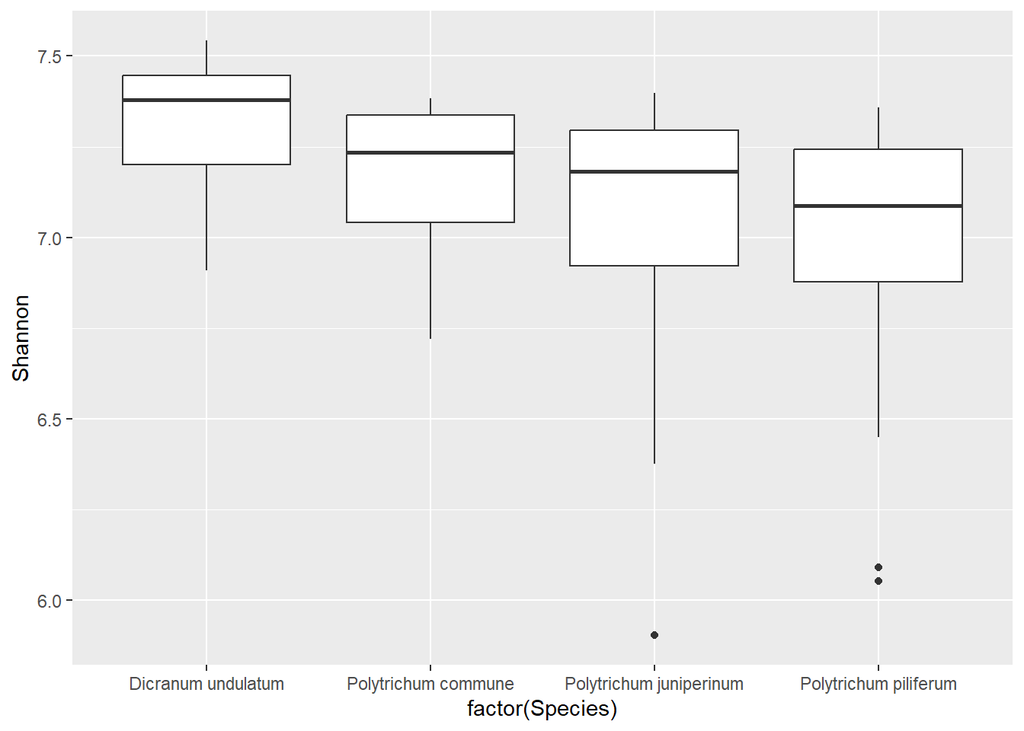

```r
plot1 <- ggplot(moss_data, aes(x = factor(Species), y = Shannon)) +
  geom_boxplot() #This adds boxplots to the plot
plot1
```

### What do we see on this plot? Do you know what the line in the middle of boxplot shows? What the boxplot shows?

1. Box itself shows the interquantile range, where the middle (50%) of the data is a median
2. Data points that fall outside 1.5 times the IQR from the quartiles are potentially outliers

Data distribution is hidden behind each box. For instance, a normal distribution could look exactly the same as a bimodal distribution. Let’s plot together with data points:

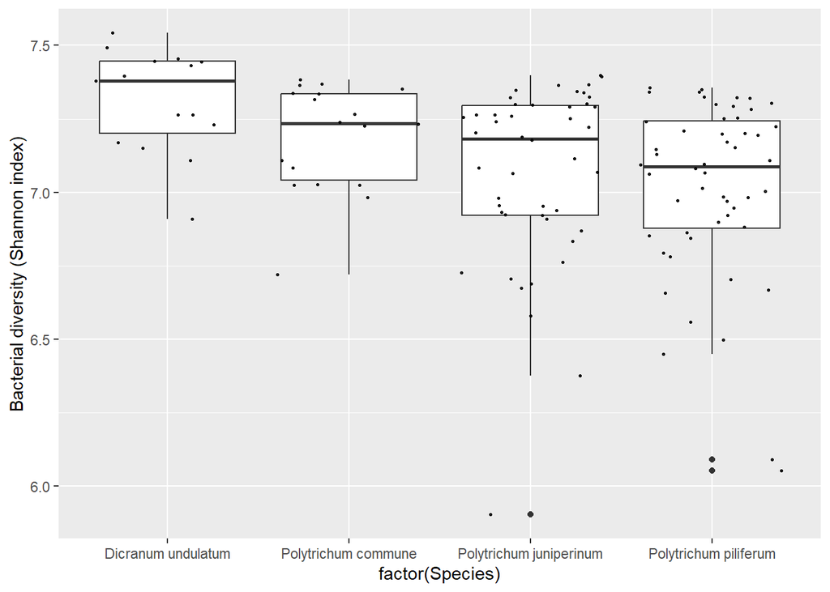

```r
# add data points to box plot (I would recommend to have it as a standard)
plot2 <- ggplot(moss_data, aes(x = factor(Species), y = Shannon)) +
  geom_boxplot() +
  #adding our data points to the map with geom_jitter (we can do it with geom_point but points will overlap most)
  geom_jitter(color="black", size=0.5, alpha=0.9) +
  #let's also assign axis labels to y and x label
  #What do we have on x axis?
  ylab("Bacterial diversity (Shannon index)")
plot2
```

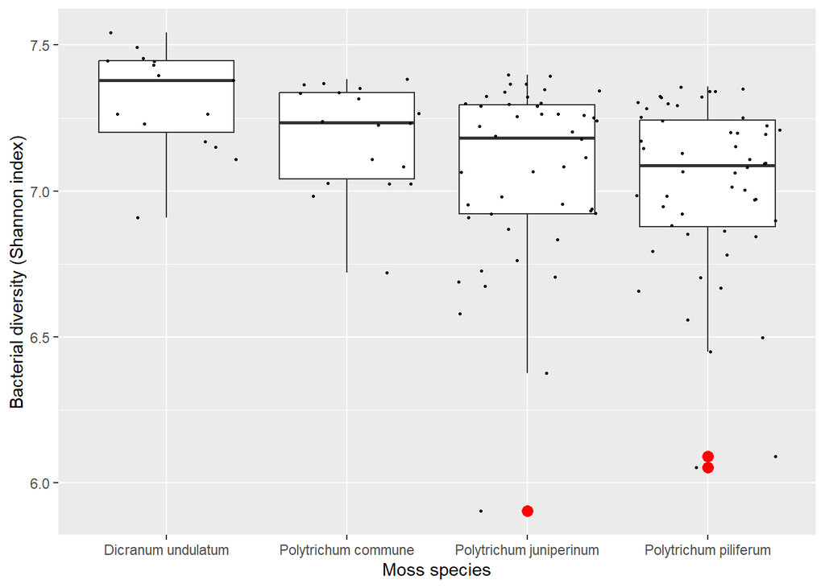

```r
#*********EXERCISE************
#so we added label to y axis, take a few minutes to add lable to x axis it should say Moss species


#emphasise outlier
#geom_boxplot(outlier.colour="",outlier.size=3)
plot2a <- ggplot(moss_data, aes(x = factor(Species), y = Shannon)) +
  geom_boxplot(outlier.colour="red",outlier.size=3) +
  geom_jitter(color="black", size=0.5, alpha=0.9) +
  xlab("Moss species") +
  ylab("Bacterial diversity (Shannon index)")
plot2a
```

### We have four different species and we would like them to be of 4 different colors?

There are several ways to do it:

1. First, you can pick and assign color yourself
- https://derekogle.com/NCGraphing/resources/colors
- https://r-graph-gallery.com/42-colors-names.html
2. using color brewers in R (packages that pre made color schemes for you), e.g., RColorBrewer
- https://r-graph-gallery.com/38-rcolorbrewers-palettes.html
- https://github.com/EmilHvitfeldt/r-color-palettes

install.packages(“RColorBrewer”), library(RColorBrewer)

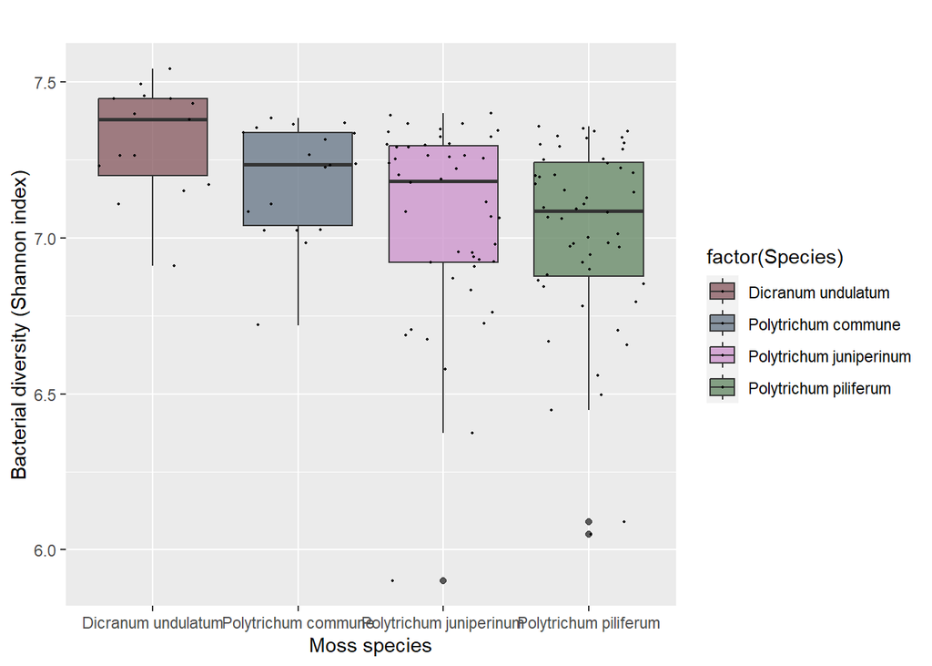

```r
#1. Picking color ourselves
#within aes () we add fill = factor(Species)
#alpha --  geom_boxplot(alpha = 0.8)

plot3a <- ggplot(moss_data, aes(x = factor(Species), y = Shannon, fill = factor(Species))) +
  geom_boxplot(alpha = 0.8) +
  geom_jitter(color="black", size=0.4, alpha=0.9) +
  xlab("Moss species") +
  ylab("Bacterial diversity (Shannon index)") +
  ggtitle("") + #Let's give it a title this time
  #assigning color manually - four species, we need four colors If we put only three colors, ggplot will complain
  scale_fill_manual(values = c("lightpink4", "slategray4","plum3", "darkseagreen4"))
plot3a
```

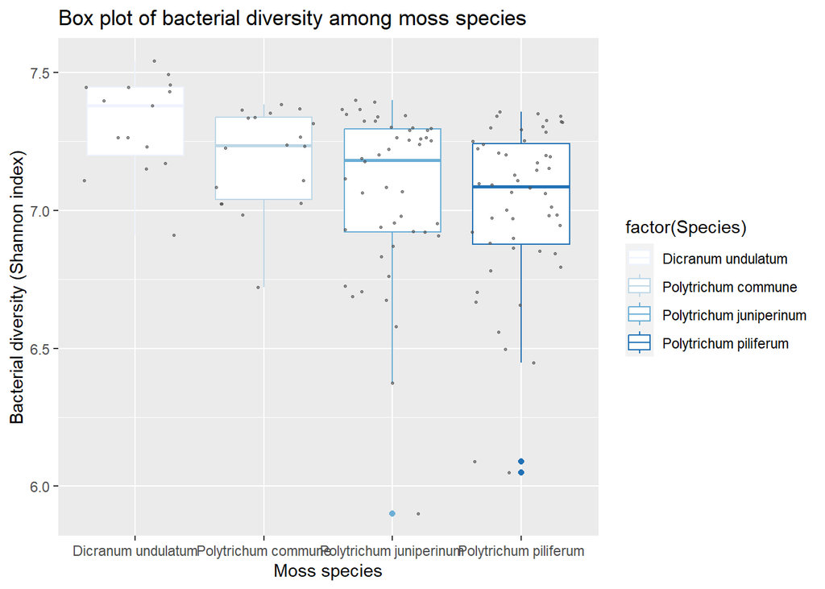

```r
#2. Using colorRbrewer
plot3c <- ggplot(moss_data, aes(x = factor(Species), y = Shannon, color = factor(Species))) +
  geom_boxplot() +
  geom_jitter(color="gray30", size=0.5, alpha=0.6) +
  xlab("Moss species") +
  ylab("Bacterial diversity (Shannon index)") +
  ggtitle("Box plot of bacterial diversity among moss species") +
  scale_color_brewer()
plot3c
```

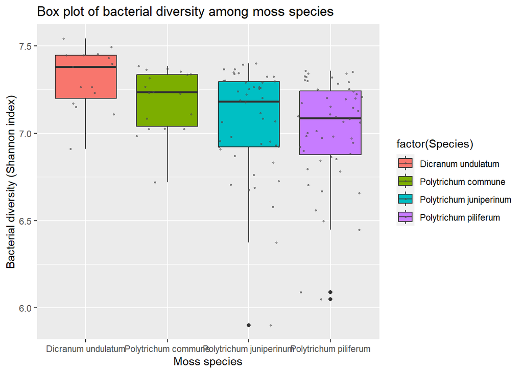

```r
#*****************EXERCISE************
#fill instead color within the aes (). What happens?
#Choose a pallette within  scale_color_brewer() function and use it for your graph
plot3d <- ggplot(moss_data, aes(x = factor(Species), y = Shannon, fill= factor(Species))) +
  geom_boxplot() +
  geom_jitter(color="gray30", size=0.5, alpha=0.6) +
  xlab("Moss species") +
  ylab("Bacterial diversity (Shannon index)") +
  ggtitle("Box plot of bacterial diversity among moss species") +
  scale_color_brewer()
plot3d
```

### What if we want to also demonstrate mean value (averages), e.g., not only median?

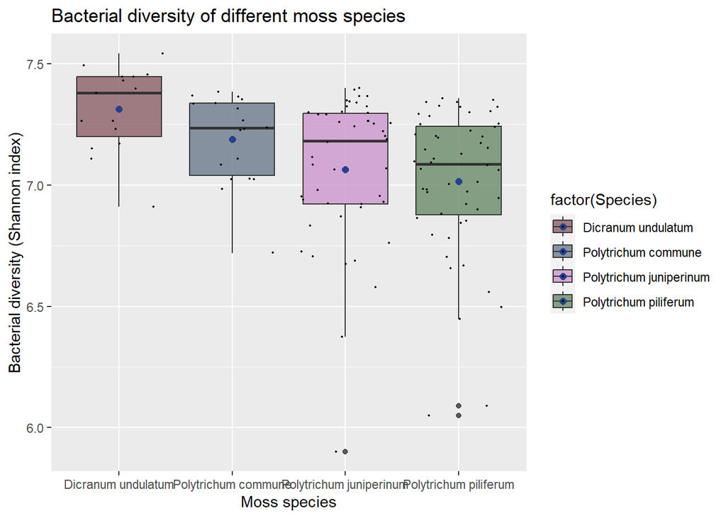

```r
#add mean to the graph -  stat_summary(fun.y=mean, geom="point", shape=20, size=14, color="", fill="")
# stat_summary is used add summary statistics to your plot
# can also add error bars usign this argument (geom = "errorbar")
plot4 <- ggplot(moss_data, aes(x = factor(Species), y = Shannon, fill = factor(Species))) +
  geom_boxplot(alpha = 0.8) +
  scale_fill_manual(values = c("lightpink4", "slategray4","plum3", "darkseagreen4")) +
  stat_summary(fun=mean, geom="point", shape=20, size=3, color="royalblue4") +
  geom_jitter(color="black", size=0.4, alpha=0.9) +
  xlab("Moss species") +
  ylab("Bacterial diversity (Shannon index)") +
  ggtitle("Bacterial diversity of different moss species")
plot4
```

### Let’s look at our data again:

```r
View(moss_data)
```

### What other factors/variables we can show on the boxplot?

#### EXERCISE:Create simple box plot plot that will show bacterial diversity by compartment and assign color to compartments. What does it show?

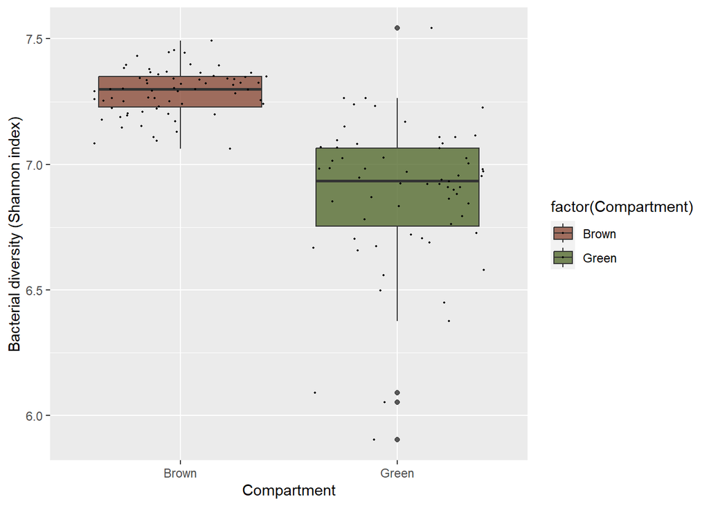

```r
plot_exerc <- ggplot(moss_data, aes(x = factor(Compartment), y = Shannon, fill = factor(Compartment))) +
  geom_boxplot(alpha = 0.8) +
  geom_jitter(color="black", size=0.4, alpha=0.9) +
  scale_fill_manual(values = c("salmon4", "darkolivegreen")) +
  xlab("Compartment") +
  ylab("Bacterial diversity (Shannon index)")
plot_exerc
```

### Now we want to visualise compartment differences for each moss species

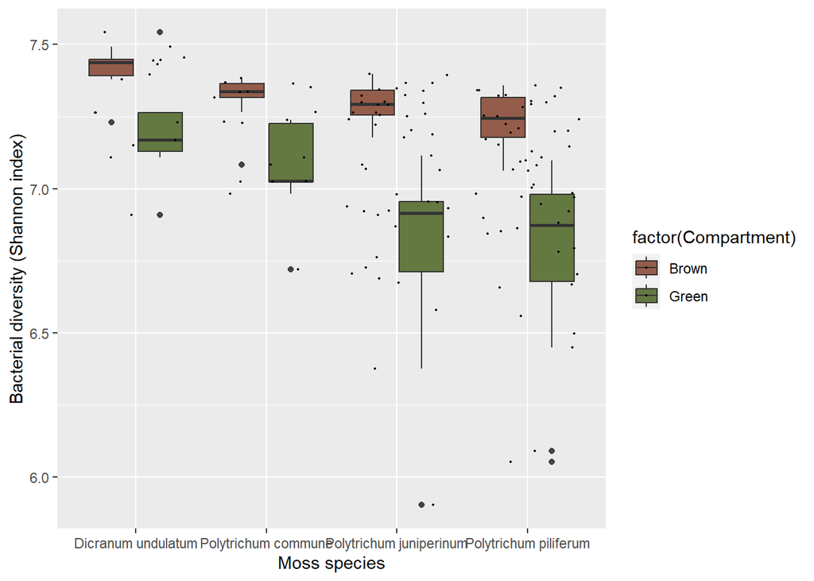

```r
#grouped
plot5 <- ggplot(moss_data, aes(x = factor(Species), y = Shannon, fill = factor(Compartment))) +
  geom_boxplot(alpha = 0.9) +
  scale_fill_manual(values = c("salmon4", "darkolivegreen"), labels=c("Brown","Green")) +
  geom_jitter(color="black", size=0.4, alpha=0.9) +
  xlab("Moss species") +
  ylab("Bacterial diversity (Shannon index)")
plot5
```

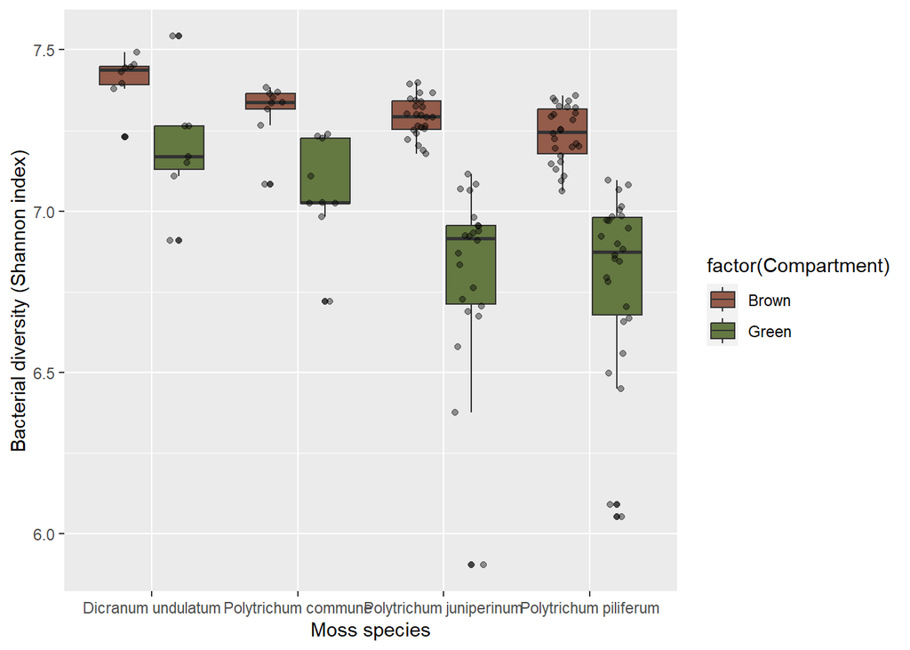

```r
#add jittered datapoints to each of the boxplot to show your data
plot5a <- ggplot(moss_data, aes(x = factor(Species), y = Shannon, fill = factor(Compartment))) +
  geom_boxplot(alpha = 0.9) +
  scale_fill_manual(values = c("salmon4", "darkolivegreen"), labels=c("Brown","Green")) +
  geom_point(position=position_jitterdodge(dodge.width=0.7, seed=0.5),alpha=0.4,show.legend = FALSE) +
  xlab("Moss species") +
  ylab("Bacterial diversity (Shannon index)")
plot5a
```

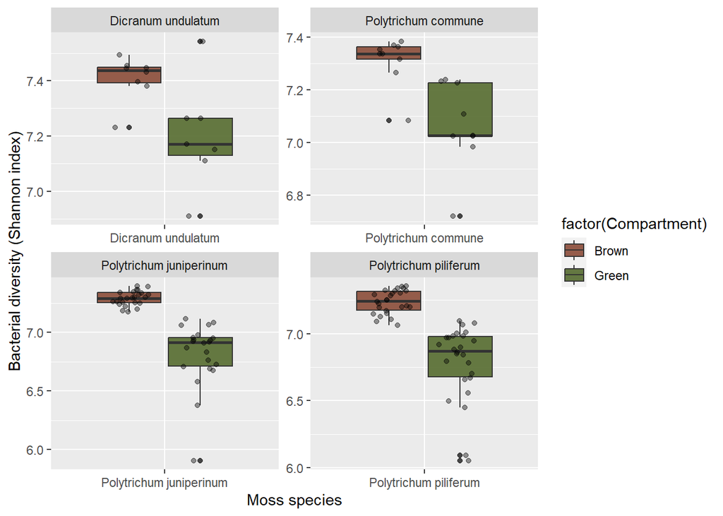

```r
#Adds individual data points on the box plots with a jittered position to avoid overplotting.
#position_jitterdodge ensures that the points are spread out within each category for clarity.
#alpha=0.2 sets the transparency of the points.

#dodge.width: This argument controls the amount to dodge in the x direction. Points belonging to different groups (usually defined by another aesthetic such as fill or color) will be shifted side by side by this amount.

#seed: This sets the seed for the random number generator used to jitter the points. Using a set seed ensures that the jittering is reproducible; the points will be jittered in the same way each time you create the plot.


#faceting - one facet per species
plot5b <- ggplot(moss_data, aes(x = factor(Species), y = Shannon, fill = factor(Compartment))) +
  geom_boxplot(alpha = 0.9) +
  facet_wrap(~ Species, scale="free") +
  scale_fill_manual(values = c("salmon4", "darkolivegreen"), labels=c("Brown","Green")) +
  geom_point(position=position_jitterdodge(dodge.width=0.7, seed=0.5),alpha=0.4,show.legend = FALSE) +
  xlab("Moss species") +
  ylab("Bacterial diversity (Shannon index)")
plot5b
```

### Modify theme of the plot

THEME is a set of aesthetic choices that affect the non-data display of a plot. This includes the display of background, grids, axis, ticks, labels, title, legend, and other non-data elements. All these changes can be done in the theme()

Useful links: https://ggplot2.tidyverse.org/reference/theme.html

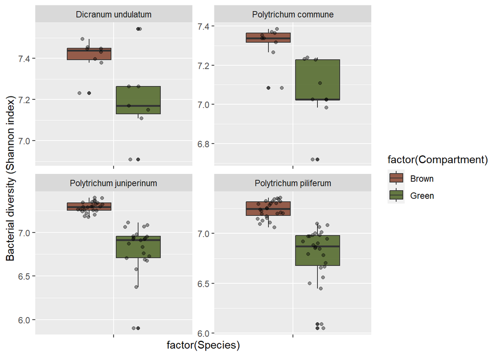

```r
#we need to modify the THEME of our plot
plot5c <- ggplot(moss_data, aes(x = factor(Species), y = Shannon, fill = factor(Compartment))) +
  geom_boxplot(alpha = 0.9) +
  scale_fill_manual(values = c("salmon4", "darkolivegreen"), labels=c("Brown","Green")) +
  geom_point(position=position_jitterdodge(dodge.width=0.7,
  seed=0.5),alpha=0.4,show.legend = FALSE) +
  ylab("Bacterial diversity (Shannon index)")+
  facet_wrap(~ Species, scale="free") +
  theme(axis.text.x = element_blank())
plot5c
```

```r
#In the THEME we can:
#1. change exis text Size and Font:
#
   #theme(text = element_text(size = 12),
   #axis.title = element_text(size = 13, face = "bold"),

#2. MOdify legend position and titles

  #legend.position = "bottom",
  #legend.title = element_blank(),
  #legend.text = element_text(size = 10))

#3. Change the name of the legend:
#+ labs(fill = "Compartment")

  #legend.text = element_text(size = 10)) +
  #labs(fill = "Compartment")

#**********FINAL PLOT  - without gridlines****************

  plot5f <- ggplot(moss_data, aes(x = factor(Species), y = Shannon, fill =
                                factor(Compartment))) +
  geom_boxplot(alpha = 0.9) +
  scale_fill_manual(values = c("salmon4", "darkolivegreen"), labels=c("Brown","Green")) +
  geom_point(aes(color = factor(Compartment)), position = position_jitterdodge(dodge.width = 0.7, seed = 0.5),
  shape = 21, stroke = 0.1, size = 2,alpha = 0.7, show.legend = FALSE) +
  ylab("Bacterial diversity (Shannon index)")+
  facet_wrap(~ Species, scale="free_x") +
  theme(axis.text.x = element_blank(),
  axis.ticks.x = element_blank(),
  text = element_text(size = 12),
  axis.title = element_text(size = 13),
  axis.text = element_text(size = 10),
  legend.position = "right",
  legend.text = element_text(size = 10),
  panel.grid.major = element_blank(), # Remove major gridlines
  panel.grid.minor = element_blank(), # Remove minor gridlines
  panel.background = element_rect(fill = "white", colour = "black")) +
  labs(x = "Moss species", fill = "Compartment")
  scale_y_continuous(limits = c(NA, NA), expand = expansion(mult = c(0, 0.02)))
```

```
## <ScaleContinuousPosition>
##  Range:
##  Limits:    0 --    1
```

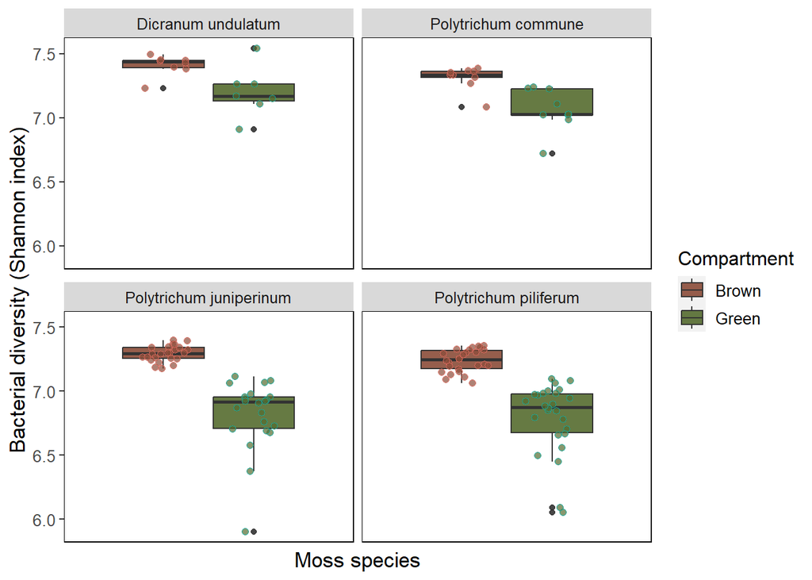

```r
  plot5f
```

### What if we want to add summary statistics?

The easiest way is to calculate it outside our plot and then add it to the plot as an extra layer

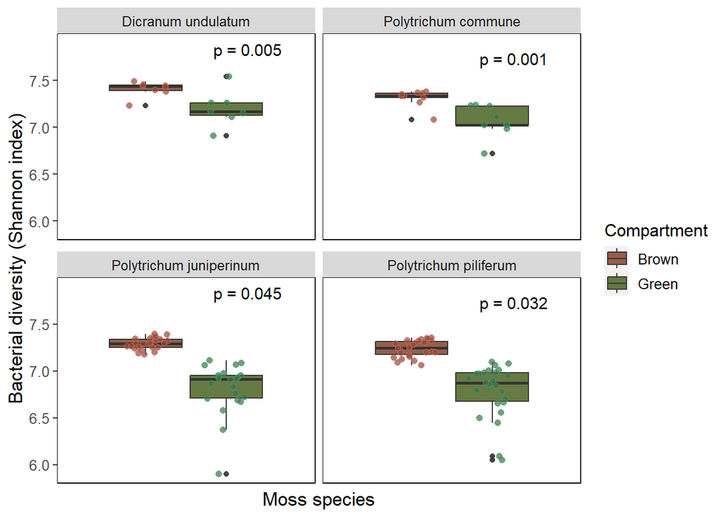

```r
#Let's say we have run our test and know the summary statistics (e.g., p-values)
#We create a data.frame that contains summery statistics for each species/compartment
p_values <- data.frame(
  Species = c('Polytrichum piliferum', 'Polytrichum juniperinum','Polytrichum commune','Dicranum undulatum'),
  Compartment = c('Brown', 'Green'), # Replace with actual compartment names if needed
  p_value = c(0.032, 0.045, 0.001, 0.005), # Replace with actual p-values from your tests
  yposition = c(7.8, 7.9) # Replace with the y-axis positions where you want the p-values to appear
  )

View(p_values)

plot5h <- plot5f +
  geom_text(data = p_values,
  aes(x = Species, y = yposition, label = paste0("p = ", p_value)),size = 4,vjust = 1,hjust = -0.4)
plot5h
```

### Boxplots are nice, but we also want to show distribution of the data on the plot.

How can we do that? We can use raincloud plots and the package “ggdist” to plot them

```r
library(ggdist)
```

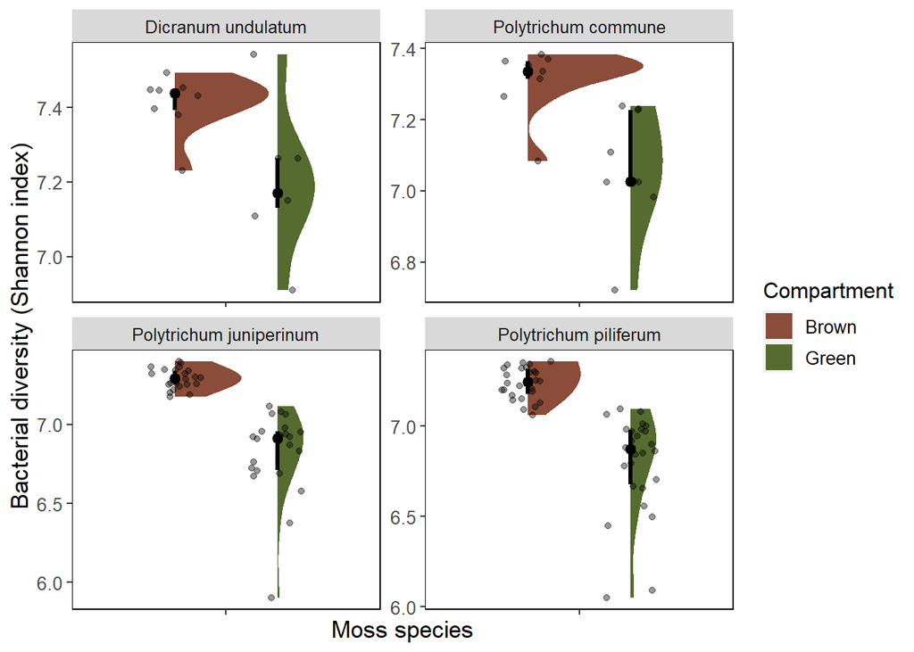

```r
plot5g <- ggplot(moss_data, aes(x = factor(Species), y = Shannon, fill = factor(Compartment))) +
  # Half-violin plot (or just the "line" of the density)
  stat_halfeye(position = position_dodge(width = 0.8),
     adjust = 1.5,  # Adjust this for smoothing
    .width = 0.5  # Control the width of the density plot
  ) +
  # Point data for individual observations
  geom_point(position = position_jitterdodge(dodge.width = 0.8), alpha = 0.4, show.legend = FALSE) +
  scale_fill_manual(values = c("salmon4", "darkolivegreen"), labels = c("Brown", "Green")) +
  ylab("Bacterial diversity (Shannon index)") +
  facet_wrap(~ Species, scale = "free") +
  theme(
    axis.text.x = element_blank(),
    text = element_text(size = 12),
    axis.title = element_text(size = 13),
    axis.text = element_text(size = 10),
    legend.position = "right",
    legend.text = element_text(size = 10),
    panel.grid.major = element_blank(), # Remove major gridlines
    panel.grid.minor = element_blank(), # Remove minor gridlines
    panel.background = element_rect(fill = "white", colour = "black")) +
  labs(x = "Moss species", fill = "Compartment")
plot5g
```

### What if we had more normally distributed data and more data points

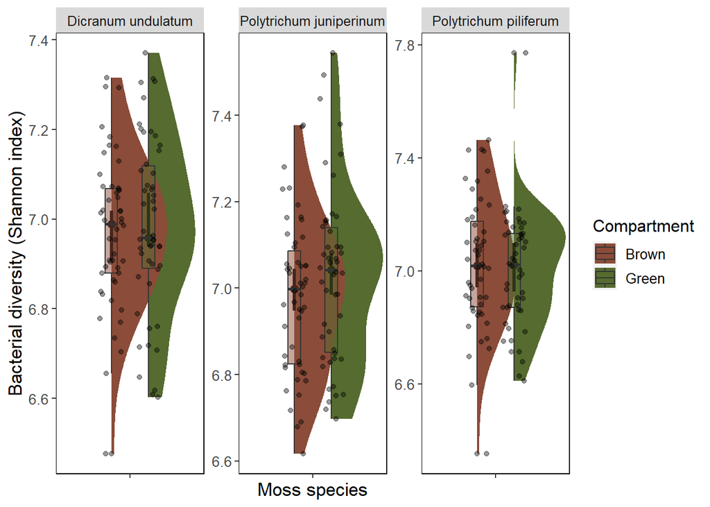

```r
#moss_datanew <- read.csv("C:/Users/.../moss_datanew.csv", sep = ",")

url <- "https://raw.githubusercontent.com/isabelle-laforest/R_UdeS_2024/main/Data/moss_data_normal.csv"
moss_data_normal <- read.csv(url, sep=',', header =TRUE)

plotnew <- ggplot(moss_data_normal, aes(x = factor(Species), y = Shannon, fill = factor(Compartment))) +
  # Half-violin plot (or just the "line" of the density)
  stat_halfeye(
    position = position_dodge(width = 0.6),
    adjust = 1.1,  # Adjust this for smoothing
    .width = 0.25  # Control the width of the density plot
  ) +
  geom_boxplot(
    width = 0.2,  # Narrower boxplot width to fit inside the violins
    position = position_dodge(width = 0.6),
    alpha = 0.5
  ) +
  # Point data for individual observations
  geom_point(
    position = position_jitterdodge(dodge.width = 0.6),
    alpha = 0.4,
    show.legend = FALSE) +
  scale_fill_manual(values = c("salmon4", "darkolivegreen"), labels = c("Brown", "Green")) +
  ylab("Bacterial diversity (Shannon index)") +
  facet_wrap(~ Species, scale = "free") +
  theme(
    axis.text.x = element_blank(),
    text = element_text(size = 12),
    axis.title = element_text(size = 13),
    axis.text = element_text(size = 10),
    legend.position = "right",
    legend.text = element_text(size = 10),
    panel.grid.major = element_blank(), # Remove major gridlines
    panel.grid.minor = element_blank(), # Remove minor gridlines
    panel.background = element_rect(fill = "white", colour = "black")) +
  labs(x = "Moss species", fill = "Compartment")
plotnew
```